# Assignment 3

## *Generating useful features for further analysis on Amazon reviews*

## Introduction

**Business Context.** You are a business consultant with new clients that are interested in analyzing reviews of their products on Amazon (as opposed to Yelp). They want to answer business questions like: "What are the most important factors driving negative reviews?", "Have there been any large changes to customer satisfaction/reviews over time?", etc.

**Business Problem.** Your main task is to **explore the given data and use the results of your investigation to engineer relevant features that could facilitate subsequent analysis and model-building**.

**Analytical Context.** The dataset provided is a large body of reviews related to movies and television left on Amazon between 1996 and 2014. When exploring our dataset, we will quickly encounter a familiar problem we discussed in the previous case: the word "good" is one of the most important words in both positive *and* negative reviews. Thus, we must develop methods to put "good" in the appropriate context.

## Loading the data

We use a dataset of around 37,000 video reviews from Amazon Instant Video and 1,700,000 movie and TV reviews, all obtained from the website: http://jmcauley.ucsd.edu/data/amazon/. Note that there are much larger datasets available at the same site. We can expect better and more consistent results on larger datasets (such as book reviews). Note that these datasets are compressed (gzipped), and they are in JSON format, with each line representing a review and each line being its own JSON object.

We begin by loading the dataset below:

```python
%matplotlib inline
```

```python
%%time
import gzip
import json
import string
import re

import nltk # imports the natural language toolkit
import pandas as pd
import plotly

from collections import Counter
from datetime import datetime
from sklearn.feature_extraction.text import CountVectorizer

nltk.download('punkt')


# we can tell pandas that our file is in gzip format and it will handle the decompression for us
# we also use `lines=True` to indicate that each line of the file is its own JSON object
instant_video = pd.read_json("reviews_Amazon_Instant_Video_5.json.gz", lines=True, compression='gzip')


# ----------
# The Movies and TV file is very big. If you have problems loading it, you can load only the first
# 100,000 reviews by using 'chunksize' (uncomment the line with 'chunksize' and comment out the line
# after that which loads the entire file into `movies_tv`). All of the analysis can be
# done in the same way using only the subset of reviews but some of the results might be different from the examples.
# ----------
# movies_tv = next(pd.read_json("reviews_Movies_and_TV_5.json.gz", lines=True, compression='gzip', chunksize=10000))
movies_tv = pd.read_json("reviews_Movies_and_TV_5.json.gz", lines=True, compression='gzip')
```

```
CPU times: user 1min 29s, sys: 2min 39s, total: 4min 9s
Wall time: 6min 34s
```

## Examining the data

We take a look at the first 5 rows of each dataset to see what attributes are available. These are

- **reviewerID:** A unique ID to identify the author of the review.
- **asin:** The ["Amazon Standard Identification Number"](https://www.amazon.com/gp/seller/asin-upc-isbn-info.html) which provides more information about the exact product and version.
- **reviewerName:** The username chosen by the reviewer.
- **helpful:** A record of how many users indicated that the review was helpful/not helpful.
- **reviewText:** The full text of the review.
- **overall:** The overall rating (1-5) left by the reviewer.
- **summary:** A short version of the review, used as the title.
- **unixReviewTime:** The date that the review was created, in [Unix Epoch](https://en.wikipedia.org/wiki/Unix_time) format.
- **reviewTime:** A human readable date giving the day, month, and year.

```python
print(len(instant_video))
print(instant_video.head(5))
```

```
37126
       reviewerID        asin                    reviewerName helpful  \
0  A11N155CW1UV02  B000H00VBQ                        AdrianaM  [0, 0]
1  A3BC8O2KCL29V2  B000H00VBQ                         Carol T  [0, 0]
2   A60D5HQFOTSOM  B000H00VBQ  Daniel Cooper "dancoopermedia"  [0, 1]
3  A1RJPIGRSNX4PW  B000H00VBQ                  J. Kaplan "JJ"  [0, 0]
4  A16XRPF40679KG  B000H00VBQ                   Michael Dobey  [1, 1]

                                          reviewText  overall  \
0  I had big expectations because I love English ...        2
1  I highly recommend this series. It is a must f...        5
2  This one is a real snoozer. Don't believe anyt...        1
3  Mysteries are interesting.  The tension betwee...        4
4  This show always is excellent, as far as briti...        5

                          summary  unixReviewTime   reviewTime
0      A little bit boring for me      1399075200   05 3, 2014
1           Excellent Grown Up TV      1346630400   09 3, 2012
2           Way too boring for me      1381881600  10 16, 2013
3     Robson Green is mesmerizing      1383091200  10 30, 2013
4  Robson green and great writing      1234310400  02 11, 2009
```

```python
print(len(movies_tv))
print(movies_tv.head(5))
```

```
1697533
       reviewerID        asin                         reviewerName helpful  \
0   ADZPIG9QOCDG5  0005019281  Alice L. Larson "alice-loves-books"  [0, 0]
1  A35947ZP82G7JH  0005019281                        Amarah Strack  [0, 0]
2  A3UORV8A9D5L2E  0005019281                      Amazon Customer  [0, 0]
3  A1VKW06X1O2X7V  0005019281           Amazon Customer "Softmill"  [0, 0]
4  A3R27T4HADWFFJ  0005019281                                 BABE  [0, 0]

                                          reviewText  overall  \
0  This is a charming version of the classic Dick...        4
1  It was good but not as emotionally moving as t...        3
2  Don't get me wrong, Winkler is a wonderful cha...        3
3  Henry Winkler is very good in this twist on th...        5
4  This is one of the best Scrooge movies out.  H...        4

                                        summary  unixReviewTime   reviewTime
0                     good version of a classic      1203984000  02 26, 2008
1                        Good but not as moving      1388361600  12 30, 2013
2         Winkler's Performance was ok at best!      1388361600  12 30, 2013
3  It's an enjoyable twist on the classic story      1202860800  02 13, 2008
4                              Best Scrooge yet      1387670400  12 22, 2013
```

We notice that `movies_tv` is extremely long with nearly 2 million reviews, and several columns seem uninteresting or hard to work with (e.g. `reviewerID`, `asin`, `reviewername`, `reviewtime`). We drop some information to make some of our later analysis more efficient. We also add a datetime column with Python datetime objects to more easily summarize the data:

```python
%%time
movies_tv['datetime'] = pd.to_datetime(movies_tv['reviewTime'], format="%m %d, %Y")
instant_video['datetime'] = pd.to_datetime(instant_video['reviewTime'], format="%m %d, %Y")
```

```
CPU times: user 5.86 s, sys: 125 ms, total: 5.99 s
Wall time: 6.15 s
```

```python
movies_tv = movies_tv.drop(columns = ['reviewerID', 'asin', 'reviewerName', 'reviewTime'])
instant_video = instant_video.drop(columns = ['reviewerID', 'asin', 'reviewerName', 'reviewTime'])

movies_tv.head(5)
```

|  | helpful | reviewText | overall | summary | unixReviewTime | datetime |
| --- | --- | --- | --- | --- | --- | --- |
| 0 | [0, 0] | This is a charming version of the classic Dick... | 4 | good version of a classic | 1203984000 | 2008-02-26 |
| 1 | [0, 0] | It was good but not as emotionally moving as t... | 3 | Good but not as moving | 1388361600 | 2013-12-30 |
| 2 | [0, 0] | Don't get me wrong, Winkler is a wonderful cha... | 3 | Winkler's Performance was ok at best! | 1388361600 | 2013-12-30 |
| 3 | [0, 0] | Henry Winkler is very good in this twist on th... | 5 | It's an enjoyable twist on the classic story | 1202860800 | 2008-02-13 |
| 4 | [0, 0] | This is one of the best Scrooge movies out. H... | 4 | Best Scrooge yet | 1387670400 | 2013-12-22 |

### Exercise 1:

#### 1.1

Plot histograms of all numeric quantities. Do you notice anything interesting about them?

**Answer.**

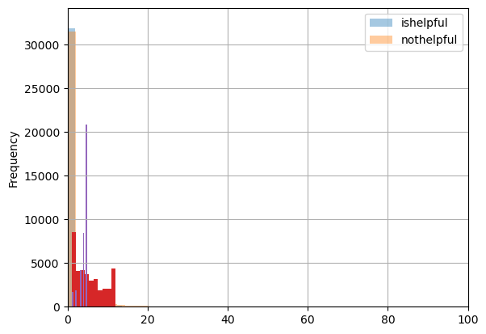

```python
import matplotlib.pyplot as plt
instant_video['ishelpful'] = instant_video['helpful'].str[0]
instant_video['nothelpful'] = instant_video['helpful'].str[1]
instant_video['year'] = instant_video['datetime'].dt.year
instant_video['month'] = instant_video['datetime'].dt.month

instant_video['ishelpful'].plot.hist(bins=250, alpha=0.4, xlim=[0,100], legend='ishelpful')
instant_video['nothelpful'].plot.hist(bins=250, alpha=0.4, xlim=[0,100], legend='nothelpful')

instant_video['year'].hist()
instant_video['month'].hist()
instant_video['overall'].hist()
```

#### 1.2

How do average ratings change over time? Plot the average rating for each year and note any trends.

**Answer.**

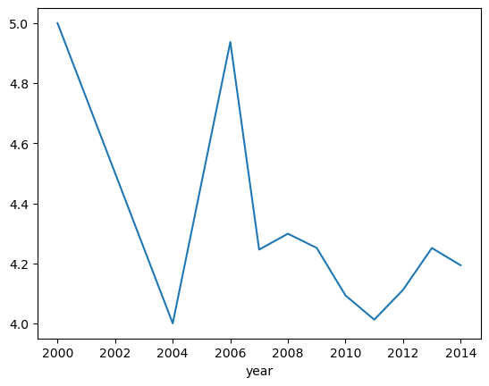

```python
instant_video.groupby('year')['overall'].mean().plot()
```

#### 1.3

Look at the average length of the review by year. Do you notice any trends?

**Answer.**

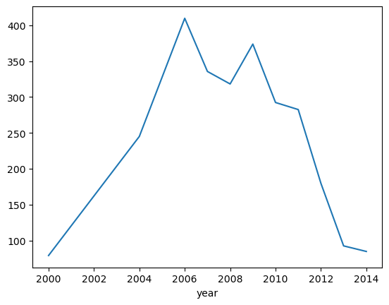

```python
instant_video['review_words_lengths'] = instant_video['reviewText'].apply(lambda x: len(nltk.word_tokenize(x)))
instant_video.groupby('year')['review_words_lengths'].mean().plot()
```

### Exercise 2:

#### 2.1

Find the ten most frequently occuring non-stop words acrooss: (i) all reviews, (ii) positive reviews, (iii) negative reviews. Do the results surprise you? Why or why not?

**Answer.**

```
season 16885
like 14748
series 12901
good 12663
just 11465
great 10594
34 10184
really 9097
love 8989
watch 8989
```

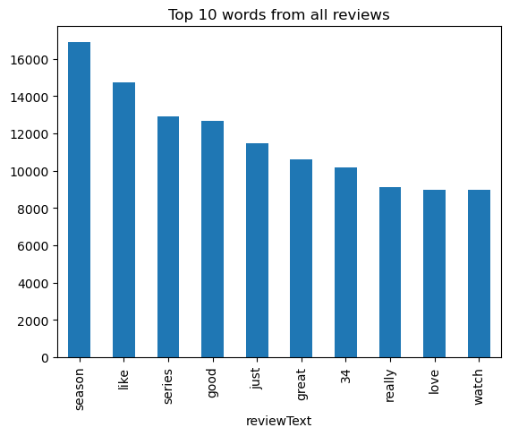

```python
nltk.download('stopwords')
from nltk.corpus import stopwords

def get_top_n_words(corpus, n=1,k=1):
    vec = CountVectorizer(ngram_range=(k,k),stop_words = 'english').fit(corpus)
    bag_of_words = vec.transform(corpus)
    sum_words = bag_of_words.sum(axis=0)
    words_freq = [(word, sum_words[0, idx]) for word, idx in vec.vocabulary_.items()]
    words_freq =sorted(words_freq, key = lambda x: x[1], reverse=True)
    return words_freq[:n]

common_words = get_top_n_words(instant_video['reviewText'], 10,1)
for word, freq in common_words:
    print(word, freq)
df1 = pd.DataFrame(common_words, columns = ['reviewText' , 'count'])
df1.groupby('reviewText').sum()['count'].sort_values(ascending=False).plot(kind='bar', title='Top 10 words from all reviews')
```

```
season 14255
series 10914
like 10206
good 9692
great 9375
love 8003
just 7342
34 7138
watch 6912
characters 6685
```

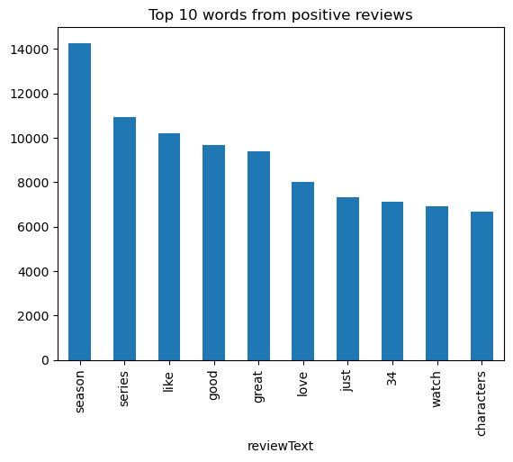

```python
positive_reviews = instant_video[instant_video['overall'] > 3]
common_words = get_top_n_words(positive_reviews['reviewText'], 10,1)
for word, freq in common_words:
    print(word, freq)
df2 = pd.DataFrame(common_words, columns = ['reviewText' , 'count'])
df2.groupby('reviewText').sum()['count'].sort_values(ascending=False).plot(kind='bar', title='Top 10 words from positive reviews')
```

```
just 2198
like 2123
movie 1784
34 1412
film 1206
really 1176
good 1148
don 1021
time 1002
people 958
```

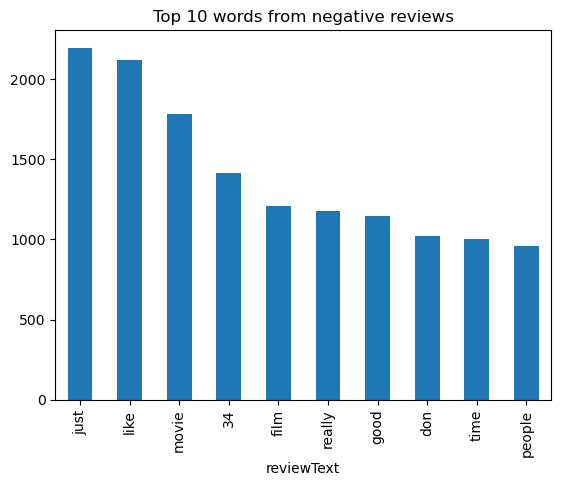

```python
negative_reviews = instant_video[instant_video['overall'] < 3]
common_words = get_top_n_words(negative_reviews['reviewText'], 10,1)
for word, freq in common_words:
    print(word, freq)
df3 = pd.DataFrame(common_words, columns = ['reviewText' , 'count'])
df3.groupby('reviewText').sum()['count'].sort_values(ascending=False).plot(kind='bar', title='Top 10 words from negative reviews')
```

#### 2.2

Find words that are indicative of bad reviews. That is, words that appear often in bad reviews and *not* in good reviews. What are these words and are they surprising?

**Answer.**

```python
common_words_positive = get_top_n_words(positive_reviews['reviewText'], 100,1)
positive = list(item[0] for item in common_words_positive)

common_words_negative = get_top_n_words(negative_reviews['reviewText'], 100,1)
negative = list(item[0] for item in common_words_negative)

only_negative = []
for item in negative:
    if item in positive:
        None
    else:
        only_negative.append(item)

print(only_negative)
```

```
['8217', 'minutes', 'boring', 'movies', 'actually', 'isn', 'guy', 'trying', 'waste', 'maybe', 'care', 'hard', 'money', 'kind', 'horror', 'big', 'stupid', 'couldn', 'need', 'sense', 'idea', 'point', 'fact', 'scenes', 'let', 'wasn']
```

### Exercise 3:

Manually inspect the first 10 negative reviews containing the word "good". What do you notice? How does this suggest we ought to proceed next?

**Answer.**

```python
negative_with_good = negative_reviews[negative_reviews['reviewText'].str.contains('good')].head(10)
negative_good_list = []
for item in negative_with_good['reviewText']:
    negative_good_list.append(item)
negative_good_list
```

```
['I watched this because the Brits usually do a good job with good production values, casting and story lines.  However, in this case it proved a waste of 5 hours. The writers, directors and editors should be ashamed to put their names in the credits.  Important things happen with no apparent reason…
 "You know the plot. Trashy kids being trashy. The &#34;good&#34; ones are the &#34;poor&#34; ones. The rich trashy kids are just &#34;bad&#34;. Another movie to help the retarded careers of this TV show's actors. They are all old and washed out. But they still try to be hip and cool with their text…
 "There's a scene in Misery where the author writes what he thinks his nurse/tormentor wants to read and suffers for his presumption. Her main problem is the fact that he cheated when he explained that his heroine was alive, but there was also the fact that he was second guessing his audience. Inste…
 "Ok, here's the thing with this show..everyone in it is excellent..I meaneveryone..the story line is fine and the writing good for the set up.I love the parents and always have but the show falls short of evergetting in the least little bit close to what it could be..I don't know whyit's a disappoi…
 "Don't waste your time with season two.  She could be fun if she wasn't so hateful inside.  Not good.  Yuck.",
 "I just do not like the main character.The only person who seems to like him, is his Mother.His ex-girlfriend hates him, his brother is furious with him, his father is dissapointed with him.Nobody (actors, seem to have a clear line on who they're supposed to be).So far, after 7 episodes,for the fir…
 "I only watched one episode. It had too much nudity and sex in it. The story line was good but didn't enjoy the rest.",
 "What show are the rest of these reviewers watching? I was excited to see this after reading the reviews, but barely made it through the first two hours. Incredibly boring, like a lavish network soap with all that implies. The history is sketchy; if you're going to twist history, at least make it f…
 "so i truly enjoyed the first two seasons of Battlestar...truly awesome, military sci/fi show, insane sets, great plot, good acting and those Cylons. all great....the end of season two had some difficulties. alot ALOT less action and more crying. lots of crying. lots of drama. lots of forgetting th…
 'I love Damien Lewis; he was awesome in Band of Brothers. But everything else I\'ve seen him in since, has failed to win me over including this new show which I wanted to like. His character (who gets out of prison for a murder he didn\'t do after 12 years,)is a cop who is quirky and spouts zen phi…
```

### Exercise 4:

Go through the list of bad reviews containing the word "good" that we found in the last question. For each review, extract the following:

1. The first word after "good"
2. The first word after "good" that is a noun or cardinal
3. The last word before "good" that is a noun or cardinal

**Answer.**

```python
nltk.download('averaged_perceptron_tagger')

def next_word(sentence):
    post = re.findall(r'good.*', sentence)
    if (len(post) > 0):
        temp = re.split(r'\s',post[0])
        if (len(temp) > 1):
            return(temp[1])
        else:
            return('')
    else:
        return('')

post_good = []
ind = 0
for sentence in negative_good_list:
    temp = next_word(sentence)
    post_good.append(temp)

nonempty = [i for i in post_good if i]
print(nonempty)
```

```
['job', 'ones', 'movie.', 'for', 'TV.', 'but', 'Guess', 'acting', 'actors,']
```

```python
nltk.pos_tag(nonempty)
```

```
[('job', 'NN'),
 ('ones', 'NNS'),
 ('movie.', 'NN'),
 ('for', 'IN'),
 ('TV.', 'NNP'),
 ('but', 'CC'),
 ('Guess', 'NNP'),
 ('acting', 'VBG'),
 ('actors,', 'NN')]
```

### Exercise 5:

We have seen that individual words are not always very informative. Look for the most informative bigrams and trigrams, in both positive and negative reviews. Show the most informative bigrams and trigrams and give a brief analysis of the n-grams you identified.

**Answer.**

```
story line 944
second season 643
sci fi 588
story lines 566
ve seen 564
looking forward 539
highly recommend 538
worth watching 503
fun watch 483
amazon prime 480
look forward 479
```

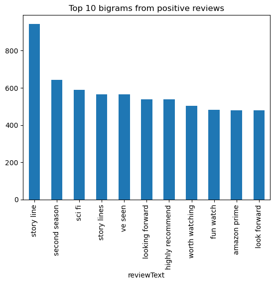

```python
common_bigrams1 = get_top_n_words(positive_reviews['reviewText'], 11,2)
for word, freq in common_bigrams1:
    print(word, freq)
df4 = pd.DataFrame(common_bigrams1, columns = ['reviewText' , 'count'])
df4.groupby('reviewText').sum()['count'].sort_values(ascending=False).plot(kind='bar', title='Top 10 bigrams from positive reviews')
```

```
looking forward season 164
keeps getting better 106
great story line 98
love love love 92
does great job 92
good story line 88
just keeps getting 83
gets better better 82
amazon instant video 80
did great job 77
look forward season 70
```

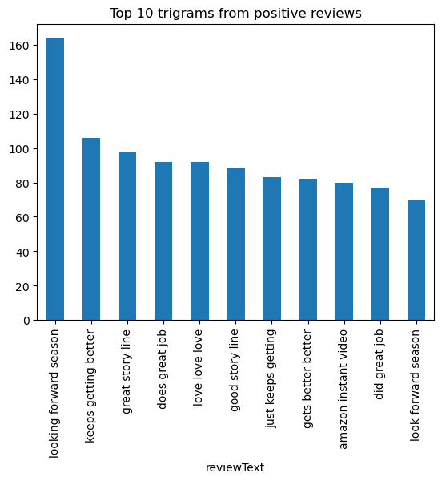

```python
common_trigrams1 = get_top_n_words(positive_reviews['reviewText'], 11,3)
for word, freq in common_trigrams1:
    print(word, freq)
df5 = pd.DataFrame(common_trigrams1, columns = ['reviewText' , 'count'])
df5.groupby('reviewText').sum()['count'].sort_values(ascending=False).plot(kind='bar', title='Top 10 trigrams from positive reviews')
```

```
waste time 150
story line 116
ve seen 114
don know 102
sci fi 92
don think 81
34 34 79
looks like 75
high school 64
special effects 63
don care 63
```

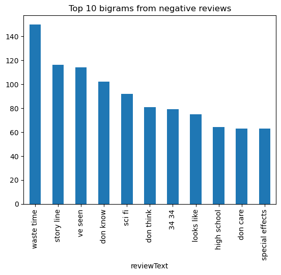

```python
common_bigrams2 = get_top_n_words(negative_reviews['reviewText'], 11,2)
for word, freq in common_bigrams2:
    print(word, freq)
df3 = pd.DataFrame(common_bigrams2, columns = ['reviewText' , 'count'])
df3.groupby('reviewText').sum()['count'].sort_values(ascending=False).plot(kind='bar', title='Top 10 bigrams from negative reviews')
```

```
don waste time 43
really wanted like 24
parental guide bomb 14
big bang theory 13
waste time money 12
bad acting bad 12
don waste money 10
dvd distribution handled 10
note following review 10
following review contain 10
reader prefers review 10
```

[figure not shown]

```python
common_trigrams2 = get_top_n_words(negative_reviews['reviewText'], 11,3)
for word, freq in common_trigrams2:
    print(word, freq)
df3 = pd.DataFrame(common_trigrams2, columns = ['reviewText' , 'count'])
df3.groupby('reviewText').sum()['count'].sort_values(ascending=False).plot(kind='bar', title='Top 10 bigrams from negative reviews')
```

### Exercise 6:

Throughout the above search for informative words, we have seen that unigrams are not enough, but important words (such as "good") are not always next to the informative words that they describe. Devise a method to extract these informative words. Provide a brief description of how you will extract the informative words.

**Answer.**

```
waste time 150
story line 116
ve seen 114
don know 102
sci fi 92
don think 81
34 34 79
looks like 75
high school 64
special effects 63
don care 63
```

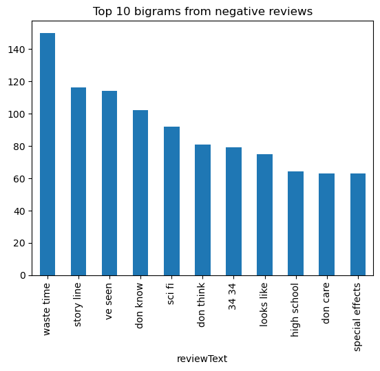

```python
common_bigrams2 = get_top_n_words(negative_reviews['reviewText'], 11,2)
for word, freq in common_bigrams2:
    print(word, freq)
df3 = pd.DataFrame(common_bigrams2, columns = ['reviewText' , 'count'])
df3.groupby('reviewText').sum()['count'].sort_values(ascending=False).plot(kind='bar', title='Top 10 bigrams from negative reviews')
```

```
don waste time 43
really wanted like 24
parental guide bomb 14
big bang theory 13
waste time money 12
bad acting bad 12
don waste money 10
dvd distribution handled 10
note following review 10
following review contain 10
reader prefers review 10
```

[figure not shown]

```python
common_trigrams2 = get_top_n_words(negative_reviews['reviewText'], 11,3)
for word, freq in common_trigrams2:
    print(word, freq)
df3 = pd.DataFrame(common_trigrams2, columns = ['reviewText' , 'count'])
df3.groupby('reviewText').sum()['count'].sort_values(ascending=False).plot(kind='bar', title='Top 10 bigrams from negative reviews')
```

### Exercise 7:

Write a function(s) that transforms a sentence into a new text list by iteratively pairing each adjective in the sentence with the next noun that follows it in the sentence. For example, the text "That was a good, long movie" should return `["good movie", "long movie"]`.

**Answer.**

```python
words = nltk.word_tokenize(example_sentence)
words_pos = nltk.pos_tag(words)
words_pos = pd.DataFrame(words_pos, columns=['word','pos'])
words_pos
```

|  | word | pos |
| --- | --- | --- |
| 0 | That | DT |
| 1 | was | VBD |
| 2 | a | DT |
| 3 | good | JJ |
| 4 | , | , |
| 5 | long | JJ |
| 6 | movie | NN |

```python
words = nltk.word_tokenize(example_sentence)
words_pos = nltk.pos_tag(words)
words_pos = pd.DataFrame(words_pos, columns=['word','pos'])
words_pos = words_pos[words_pos['pos'].isin(['NN','NNS','NNP','NNPS', 'JJ'])]
words_pos = words_pos.reset_index()
words_pos = words_pos.drop(columns=['index'])
words_pos
```

|  | word | pos |
| --- | --- | --- |
| 0 | good | JJ |
| 1 | long | JJ |
| 2 | movie | NN |

```python
words = nltk.word_tokenize(example_sentence)
words_pos = nltk.pos_tag(words)
words_pos
```

```
[('That', 'DT'),
 ('was', 'VBD'),
 ('a', 'DT'),
 ('good', 'JJ'),
 (',', ','),
 ('long', 'JJ'),
 ('movie', 'NN')]
```

```python
def get_dataframe_pos (sentence):
    words = nltk.word_tokenize(example_sentence)
    words_pos = nltk.pos_tag(words)
    words_pos = pd.DataFrame(words_pos, columns=['word','pos'])
    words_pos = words_pos[words_pos['pos'].isin(['NN','NNS','NNP','NNPS', 'JJ'])]
    words_pos = words_pos.reset_index()
    words_pos = words_pos.drop(columns=['index'])
    return (words_pos)
```